# Progress Memo 1

Final Project  
Data Science 1 with R (STAT 301-2)

Author

Karthik Sathish

Published

February 6, 2024

**Github Repo Link**

[My Github Repo Link](https://github.com/stat301-2-2024-winter/final-project-2-kvsathish.git)

## Prediction Problem

As an avid basketball fan, I wanted to look into what qualifies college basketball players to be drafted into the National Basketball Association (NBA). Specifically, I am interested to see if it is possible to predict which players from college would get drafted into the NBA, based on a range of statistics collected across all seasons played at the collegiate level. Furthermore, it would be also very interesting to distinguish between players drafted as a lottery pick in the first round (first fourteen picks), a latter pick in the rest of the first round, or a pick in the second round of the NBA draft.

For this proposed analysis, the `pick` variable is chosen as the target variable within the `cbb_players` dataset. This values for this variable indicate what number pick in the NBA draft each of the players achieved. Although this variable is a numerical variable, the type of prediction problem that I’ve described is a complex classification problem. The `pick` variable is the variable of interest and it will be utilized to organize college basketball players in the following categories: “Not drafted”, “Lottery Pick”, “Later First Round”, or “Second Round”. Essentially, this is a categorical outcome and all of the players in the dataset will be assigned to one of these four categories. Since there are separate classes for identification and prediction, this is a classification problem. With four possible outcomes, it is a multi-class classification problem.

The resulting prediction model might not change the world, but it piques my interest. Basketball has always been my favorite sport to watch, and it is so exciting that I am able to conduct a thorough analysis combining basketball at the collegiate and pro level. I’ve always thought about why some of the greatest college basketball players do not pan out in the NBA, and I feel as though this statistical analysis may reveal which factors are most important for an appropriate transition to the pro level. A prediction model would be useful to identify which prospective players may translate best into the NBA. This model could also help future players mold their game toward a more specific prototype to achieve more success in the sport. Again, I think it would be very interesting to also possibly see how the prototype of NBA draftees had changed over time. All in all, I believe this would be an extremely fun project.

## Data Source

The source of my data is a user on `Kaggle.com`, named Aditya Kumar. They are a computer science major at the University of Southern California with roots in Los Angeles, California. The data card is named `College Basketball 2009-2021 + NBA Advanced Stats`[^1]. Although all the stats were compiled by Aditya, the raw statistical data should be credited to Bart Torvik[^2].

As of right now, I plan on utilizing a singular dataset called `CollegeBasketballPlayers2009-2021.csv` to compare over 4500 college basketball players from 2009 to 2021. However, if I feel as though there is not enough observations or predictors, or if I may require some validative measures, I may dive into the `CollegeBasketballPlayers2022.csv`, `latest_RAPTOR_by_player.csv`, `modern_RAPTOR_by_player.csv` to combine information and analyze the data more holistically. If I need to join these datasets together, I plan on aligning variables based on similarity and function. I think I will be able to combine the data seamlessly if need be.

## Data Quality Check

#### Reading in dataset

```r
# read in dataset
cbb_players <- read_csv("data/CollegeBasketballPlayers2009-2021.csv")

kable(head(cbb_players))
```

| player_name | team | conf | GP | Min_per | Ortg | usg | eFG | TS_per | ORB_per | DRB_per | AST_per | TO_per | FTM | FTA | FT_per | twoPM | twoPA | twoP_per | TPM | TPA | TP_per | blk_per | stl_per | ftr | yr | ht | num | porpag | adjoe | … |
| --- | --- | --- | --- | --- | --- | --- | --- | --- | --- | --- | --- | --- | --- | --- | --- | --- | --- | --- | --- | --- | --- | --- | --- | --- | --- | --- | --- | --- | --- | --- |
| DeAndrae Ross | South Alabama | SB | 26 | 29.5 | 97.3 | 16.6 | 42.5 | 44.43 | 1.6 | 4.6 | 15.8 | 16.3 | 10 | 14 | 0.714 | 26 | 68 | 0.382 | 13 | 39 | 0.333 | 0.3 | 1.5 | 13.1 | So | 2-Jun | NA | 0.258086 | 89.39380 | … |
| Pooh Williams | Utah St. | WAC | 34 | 60.9 | 108.3 | 14.9 | 52.4 | 54.48 | 3.8 | 6.3 | 13.6 | 19.8 | 30 | 45 | 0.667 | 56 | 113 | 0.496 | 20 | 51 | 0.392 | 1.0 | 1.1 | 27.4 | So | 4-Jun | NA | 1.334920 | 100.06600 | … |
| Jesus Verdejo | South Florida | BE | 27 | 72.0 | 96.2 | 21.8 | 45.7 | 47.98 | 2.1 | 8.0 | 14.7 | 15.9 | 45 | 67 | 0.672 | 67 | 157 | 0.427 | 50 | 154 | 0.325 | 0.0 | 0.9 | 21.5 | Sr | 4-Jun | NA | 2.274070 | 104.10700 | … |
| Mike Hornbuckle | Pepperdine | WCC | 30 | 44.5 | 97.7 | 16.0 | 53.6 | 53.69 | 4.1 | 9.4 | 13.7 | 23.8 | 14 | 27 | 0.519 | 25 | 63 | 0.397 | 28 | 62 | 0.452 | 0.8 | 1.9 | 21.6 | Sr | 4-Jun | NA | 0.552857 | 93.20860 | … |
| Anthony Brown | Pacific | BW | 33 | 56.2 | 96.5 | 22.0 | 52.8 | 54.31 | 8.3 | 18.6 | 8.2 | 22.7 | 64 | 114 | 0.561 | 93 | 176 | 0.528 | 0 | 0 | 0.000 | 1.9 | 1.3 | 64.8 | Sr | 8-Jun | NA | 1.060130 | 97.85540 | … |
| Nick Rodgers | Butler | Horz | 6 | 0.7 | 0.0 | 0.0 | 0.0 | 0.00 | 0.0 | 26.3 | 40.8 | 0.0 | 0 | 0 | 0.000 | 0 | 0 | 0.000 | 0 | 0 | 0.000 | 0.0 | 0.0 | 0.0 | Jr | 1-Jun | NA | -0.478278 | -7.62129 | … |

In the dataset above, there are 66 total variables and 61,061 total observations. Moreover, there are 7 categorical variables as well as 59 numerical variables. In terms of missingness, there are missing values present in 35 of the variables. A formatted table below reveals the `missing_percentage` or the percentage of values that are missing in each column with missingness. I plan to account for these `NA` values on top of the missing values in `pick` during my analysis of the dataset to make predictive models.

Variables with Missing Values

| Variable | Missing Percentage |
| --- | --- |
| pick | 97.6498911 |
| Rec Rank | 69.7515599 |
| dunksmade/(dunksmade+dunksmiss) | 54.8795467 |
| midmade/(midmade+midmiss) | 17.0075826 |
| rimmade/(rimmade+rimmiss) | 16.5572133 |
| rimmade | 10.3650448 |
| rimmade+rimmiss | 10.3650448 |
| midmade | 10.3650448 |
| midmade+midmiss | 10.3650448 |
| dunksmade | 10.3650448 |
| dunksmiss+dunksmade | 10.3650448 |
| num | 7.8446144 |
| ast/tov | 7.7414389 |
| ...65 | 7.6710175 |
| ht | 0.1408428 |
| drtg | 0.0736968 |
| adrtg | 0.0736968 |
| dporpag | 0.0736968 |
| stops | 0.0736968 |
| bpm | 0.0736968 |
| obpm | 0.0736968 |
| dbpm | 0.0736968 |
| gbpm | 0.0736968 |
| ogbpm | 0.0736968 |
| dgbpm | 0.0736968 |
| ...66 | 0.0736968 |
| yr | 0.0655083 |
| mp | 0.0622328 |
| oreb | 0.0622328 |
| dreb | 0.0622328 |
| treb | 0.0622328 |
| ast | 0.0622328 |
| stl | 0.0622328 |
| blk | 0.0622328 |
| pts | 0.0622328 |

## Target Variable Analysis

| skim_type | skim_variable | n_missing | complete_rate | numeric.mean | numeric.sd | numeric.p0 | numeric.p25 | numeric.p50 | numeric.p75 | numeric.p100 | numeric.hist |
| --- | --- | --- | --- | --- | --- | --- | --- | --- | --- | --- | --- |
| numeric | data | 59626 | 0.0235011 | 33.16376 | 16.6584 | 1 | 19 | 34 | 48 | 60 | ▅▆▇▇▇ |

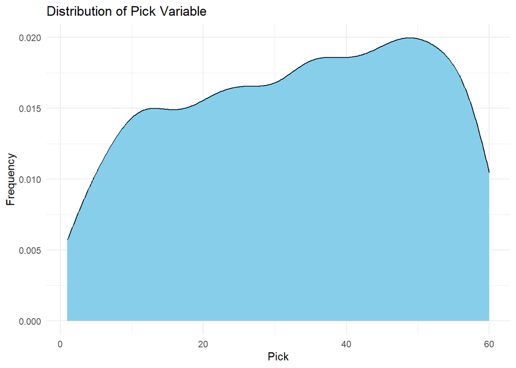

The target variable `pick` has been analyzed above. One major issue is with missingness. Since `pick` is a numerical variable, all players that were not drafted have a missing value. It will be necessary to convert `pick` to a categorical variable where players that didn’t get drafter (have no pick value) make up a new category. I will also have to make categories for lottery pick, later first round pick, and second round pick.

## Misc

#### Timeline:

Week 1 - Figure out how to attack the prediction problem (Which players get drafted to the NBA?).

Week 2 - Plan out the predictive modelling, split the data, and begin creating graphics to serve as evidence in addressing the problem.

Week 3 - Finish training all the models and building all the necessary graphics for proper analysis of the data. Decide whether additional datasets should be used.

Week 4 - Write up all the analysis and make sure to weigh the context behind all the predictive modelling for effective conclusions.

## Footnotes

[^1]: Found on https://www.kaggle.com/datasets/adityak2003/college-basketball-players-20092021/data
[^2]: Found on https://barttorvik.com/